# Food Recipe Data Analysis

Alisha Siddiqui

12/2/2019

# **Introduction**

Food is an essential component of our individual and social life. In this direction, food-oriented blogs and websites have blossomed. The data is being contributed by foodies, gourmets and cooks. The analysis of this usercontributed data provides interesting insight in understanding cuisines habits and cultures.

The objective of this project is to analyze food recipe data. This data is available at food.com. I intent to cover the below in this project scope:- 1. The average time of preparation of recipes. 2. Over what period was data collected and reviewed. 3. How are the variables correlated to each other.

This is going to help determine what are the factors that lead to successful/unsuccessful recipes. Looking at the above inferences, a blogger would know what is the average preparation time for recipes, how long does it take to be reviewed after submission and how are reviews correlated to year of submission.

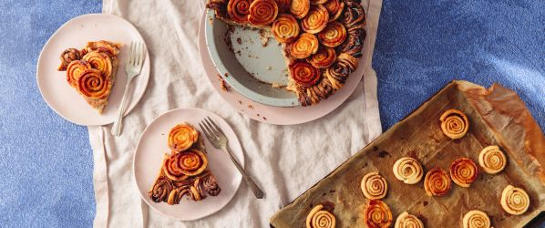

# **Data Preparation**

## The data was scraped from Food.com

```r
#Loading the necessary packages and libraries
library(tidyverse)
library(lubridate)
library(extrafont)
library(scales)
library(ggridges)
library(corrplot)
library(Hmisc)
library(reshape2)

#Reading datasets
recipes_data <- read_csv("~/desktop/alisha/RAW_recipes.csv")
reviews_data <- read_csv("~/desktop/alisha/RAW_interactions.csv")

#combining recipe and review data files
combine_food <- inner_join(recipes_data, reviews_data, by = c("id" = "recipe_id"))

#Displaying the structure of final file
str(combine_food)
```

```
## Classes 'spec_tbl_df', 'tbl_df', 'tbl' and 'data.frame': 1132367 obs. of  16 variables:
##  $ name          : chr  "arriba   baked winter squash mexican style" "arriba   baked winter squash mexican style" "arriba   baked winter squash mexican style" "a bit different  breakfast pizza" ...
##  $ id            : num  137739 137739 137739 31490 31490 ...
##  $ minutes       : num  55 55 55 30 30 30 30 130 45 45 ...
##  $ contributor_id: num  47892 47892 47892 26278 26278 ...
##  $ submitted     : Date, format: "2005-09-16" "2005-09-16" ...
##  $ tags          : chr  "['60-minutes-or-less', 'time-to-make', 'course', 'main-ingredient', 'cuisine', 'preparation', 'occasion', 'nort"| __truncated__ "['60-minutes-or-less', 'time-to-make', 'course', 'main-ingredient', 'cuisine', 'preparation', 'occasion', 'nort"| __truncated__ "['60-minutes-o…
##  $ nutrition     : chr  "[51.5, 0.0, 13.0, 0.0, 2.0, 0.0, 4.0]" "[51.5, 0.0, 13.0, 0.0, 2.0, 0.0, 4.0]" "[51.5, 0.0, 13.0, 0.0, 2.0, 0.0, 4.0]" "[173.4, 18.0, 0.0, 17.0, 22.0, 35.0, 1.0]" ...
##  $ n_steps       : num  11 11 11 9 9 9 9 6 11 11 ...
##  $ steps         : chr  "['make a choice and proceed with recipe', 'depending on size of squash , cut into half or fourths', 'remove see"| __truncated__ "['make a choice and proceed with recipe', 'depending on size of squash , cut into half or fourths', 'remove see"| __truncated__ "['make a choic…
##  $ description   : chr  "autumn is my favorite time of year to cook! this recipe \r\ncan be prepared either spicy or sweet, your choice!"| __truncated__ "autumn is my favorite time of year to cook! this recipe \r\ncan be prepared either spicy or sweet, your choice!"| __truncated__ "autumn is my f…
##  $ ingredients   : chr  "['winter squash', 'mexican seasoning', 'mixed spice', 'honey', 'butter', 'olive oil', 'salt']" "['winter squash', 'mexican seasoning', 'mixed spice', 'honey', 'butter', 'olive oil', 'salt']" "['winter squash', 'mexican seasoning', 'mixed spice', 'honey', 'butter', 'olive …
##  $ n_ingredients : num  7 7 7 6 6 6 6 13 11 11 ...
##  $ user_id       : num  4470 593927 178427 28603 346277 ...
##  $ date          : Date, format: "2006-02-18" "2010-08-21" ...
##  $ rating        : num  5 5 5 0 5 4 5 4 4 5 ...
##  $ review        : chr  "I used an acorn squash and recipe#137681 Sweet Mexican spice blend. Only used 1 tsp honey & 1 tsp butter betwee"| __truncated__ "This was a nice change. I used butternut squash and the sweet option using a good local honey and unsalted butt"| __truncated__ "Excellent reci…
```

```r
head(combine_food, 10)
```

| name | id | minutes | contributor_id | submitted | tags | nutrition | n_steps | steps | description | ingredients | n_ingredients | user_id | date | rating | review |
| --- | --- | --- | --- | --- | --- | --- | --- | --- | --- | --- | --- | --- | --- | --- | --- |
| arriba baked winter squash mexican style | 137739 | 55 | 47892 | 2005-09-16 | ['60-minutes-or-less', 'time-to-make', 'course', 'main-ingredient', 'cuisine', 'preparation', 'occasion', 'north-american', 'side-dishes', 'vegetables', 'mexican', 'easy', 'fall', 'holiday-event', 've… | [51.5, 0.0, 13.0, 0.0, 2.0, 0.0, 4.0] | 11 | ['make a choice and proceed with recipe', 'depending on size of squash , cut into half or fourths', 'remove seeds', 'for spicy squash , drizzle olive oil or melted butter over each cut squash piece', … | autumn is my favorite time of year to cook! this recipe \r\ncan be prepared either spicy or sweet, your choice!\r\ntwo of my posted mexican-inspired seasoning mix recipes are offered as suggestions. | ['winter squash', 'mexican seasoning', 'mixed spice', 'honey', 'butter', 'olive oil', 'salt'] | 7 | 4470 | 2006-02-18 | 5 | I used an acorn squash and recipe#137681 Sweet Mexican spice blend. Only used 1 tsp honey & 1 tsp butter between both halves,, sprinkled the squash liberally with the spice mix. Baked covered for 45 m… |
| arriba baked winter squash mexican style | 137739 | 55 | 47892 | 2005-09-16 | ['60-minutes-or-less', 'time-to-make', 'course', 'main-ingredient', 'cuisine', 'preparation', 'occasion', 'north-american', 'side-dishes', 'vegetables', 'mexican', 'easy', 'fall', 'holiday-event', 've… | [51.5, 0.0, 13.0, 0.0, 2.0, 0.0, 4.0] | 11 | ['make a choice and proceed with recipe', 'depending on size of squash , cut into half or fourths', 'remove seeds', 'for spicy squash , drizzle olive oil or melted butter over each cut squash piece', … | autumn is my favorite time of year to cook! this recipe \r\ncan be prepared either spicy or sweet, your choice!\r\ntwo of my posted mexican-inspired seasoning mix recipes are offered as suggestions. | ['winter squash', 'mexican seasoning', 'mixed spice', 'honey', 'butter', 'olive oil', 'salt'] | 7 | 593927 | 2010-08-21 | 5 | This was a nice change. I used butternut squash and the sweet option using a good local honey and unsalted butter. I did not add salt. We ate this on top of recipe#322603 with Balkan yogurt. I may mak… |
| arriba baked winter squash mexican style | 137739 | 55 | 47892 | 2005-09-16 | ['60-minutes-or-less', 'time-to-make', 'course', 'main-ingredient', 'cuisine', 'preparation', 'occasion', 'north-american', 'side-dishes', 'vegetables', 'mexican', 'easy', 'fall', 'holiday-event', 've… | [51.5, 0.0, 13.0, 0.0, 2.0, 0.0, 4.0] | 11 | ['make a choice and proceed with recipe', 'depending on size of squash , cut into half or fourths', 'remove seeds', 'for spicy squash , drizzle olive oil or melted butter over each cut squash piece', … | autumn is my favorite time of year to cook! this recipe \r\ncan be prepared either spicy or sweet, your choice!\r\ntwo of my posted mexican-inspired seasoning mix recipes are offered as suggestions. | ['winter squash', 'mexican seasoning', 'mixed spice', 'honey', 'butter', 'olive oil', 'salt'] | 7 | 178427 | 2011-12-05 | 5 | Excellent recipe! I used butternut squash and the sweet option. The mexican spice mix put this over the top. Thanks for sharing. |
| a bit different breakfast pizza | 31490 | 30 | 26278 | 2002-06-17 | ['30-minutes-or-less', 'time-to-make', 'course', 'main-ingredient', 'cuisine', 'preparation', 'occasion', 'north-american', 'breakfast', 'main-dish', 'pork', 'american', 'oven', 'easy', 'kid-friendly'… | [173.4, 18.0, 0.0, 17.0, 22.0, 35.0, 1.0] | 9 | ['preheat oven to 425 degrees f', 'press dough into the bottom and sides of a 12 inch pizza pan', 'bake for 5 minutes until set but not browned', 'cut sausage into small pieces', 'whisk eggs and milk … | this recipe calls for the crust to be prebaked a bit before adding ingredients. feel free to change sausage to ham or bacon. this warms well in the microwave for those late risers. | ['prepared pizza crust', 'sausage patty', 'eggs', 'milk', 'salt and pepper', 'cheese'] | 6 | 28603 | 2002-08-19 | 0 | Have not tried this, but it sounds delicious. Reminds me of a layover I had at the Atlanta airport. I had a ham, egg, and cheese pizza at one of the pizza chain places on the concourse. About $2.99 wi… |
| a bit different breakfast pizza | 31490 | 30 | 26278 | 2002-06-17 | ['30-minutes-or-less', 'time-to-make', 'course', 'main-ingredient', 'cuisine', 'preparation', 'occasion', 'north-american', 'breakfast', 'main-dish', 'pork', 'american', 'oven', 'easy', 'kid-friendly'… | [173.4, 18.0, 0.0, 17.0, 22.0, 35.0, 1.0] | 9 | ['preheat oven to 425 degrees f', 'press dough into the bottom and sides of a 12 inch pizza pan', 'bake for 5 minutes until set but not browned', 'cut sausage into small pieces', 'whisk eggs and milk … | this recipe calls for the crust to be prebaked a bit before adding ingredients. feel free to change sausage to ham or bacon. this warms well in the microwave for those late risers. | ['prepared pizza crust', 'sausage patty', 'eggs', 'milk', 'salt and pepper', 'cheese'] | 6 | 346277 | 2006-08-27 | 5 | This recipe was wonderful. Instead of using the precooked sausage I substituted uncooked sausage then cooked and drained it. It turned out perfect! |
| a bit different breakfast pizza | 31490 | 30 | 26278 | 2002-06-17 | ['30-minutes-or-less', 'time-to-make', 'course', 'main-ingredient', 'cuisine', 'preparation', 'occasion', 'north-american', 'breakfast', 'main-dish', 'pork', 'american', 'oven', 'easy', 'kid-friendly'… | [173.4, 18.0, 0.0, 17.0, 22.0, 35.0, 1.0] | 9 | ['preheat oven to 425 degrees f', 'press dough into the bottom and sides of a 12 inch pizza pan', 'bake for 5 minutes until set but not browned', 'cut sausage into small pieces', 'whisk eggs and milk … | this recipe calls for the crust to be prebaked a bit before adding ingredients. feel free to change sausage to ham or bacon. this warms well in the microwave for those late risers. | ['prepared pizza crust', 'sausage patty', 'eggs', 'milk', 'salt and pepper', 'cheese'] | 6 | 319943 | 2009-07-18 | 4 | We liked this, but the I only baked for 15 minutes and the crust was too browned on the bottom. That could be my oven, but I haven't had issues in the past. I too used uncooked sausage, but cooked it … |
| a bit different breakfast pizza | 31490 | 30 | 26278 | 2002-06-17 | ['30-minutes-or-less', 'time-to-make', 'course', 'main-ingredient', 'cuisine', 'preparation', 'occasion', 'north-american', 'breakfast', 'main-dish', 'pork', 'american', 'oven', 'easy', 'kid-friendly'… | [173.4, 18.0, 0.0, 17.0, 22.0, 35.0, 1.0] | 9 | ['preheat oven to 425 degrees f', 'press dough into the bottom and sides of a 12 inch pizza pan', 'bake for 5 minutes until set but not browned', 'cut sausage into small pieces', 'whisk eggs and milk … | this recipe calls for the crust to be prebaked a bit before adding ingredients. feel free to change sausage to ham or bacon. this warms well in the microwave for those late risers. | ['prepared pizza crust', 'sausage patty', 'eggs', 'milk', 'salt and pepper', 'cheese'] | 6 | 674022 | 2011-04-10 | 5 | No leftovers here. As Coleen114 mentioned this cooks fast. 10 minutes total for us till it was perfect brown but if we hadn't been watching it could have been disaster. Ovens vary but we had ours high… |
| all in the kitchen chili | 112140 | 130 | 196586 | 2005-02-25 | ['time-to-make', 'course', 'preparation', 'main-dish', 'chili', 'crock-pot-slow-cooker', 'dietary', 'equipment', '4-hours-or-less'] | [269.8, 22.0, 32.0, 48.0, 39.0, 27.0, 5.0] | 6 | ['brown ground beef in large pot', 'add chopped onions to ground beef when almost brown and sautee until wilted', 'add all other ingredients', 'add kidney beans if you like beans in your chili', 'cook… | this modified version of 'mom's' chili was a hit at our 2004 christmas party. we made an extra large pot to have some left to freeze but it never made it to the freezer. it was a favorite by all. perf… | ['ground beef', 'yellow onions', 'diced tomatoes', 'tomato paste', 'tomato soup', 'rotel tomatoes', 'kidney beans', 'water', 'chili powder', 'ground cumin', 'salt', 'lettuce', 'cheddar cheese'] | 13 | 255952 | 2005-10-27 | 4 | I added black beans and corn to this and LOVED it! Goes great with Cornbread and milk! |
| alouette potatoes | 59389 | 45 | 68585 | 2003-04-14 | ['60-minutes-or-less', 'time-to-make', 'course', 'main-ingredient', 'preparation', 'occasion', 'side-dishes', 'eggs-dairy', 'potatoes', 'vegetables', 'oven', 'easy', 'dinner-party', 'holiday-event', '… | [368.1, 17.0, 10.0, 2.0, 14.0, 8.0, 20.0] | 11 | ['place potatoes in a large pot of lightly salted water and bring to a gentle boil', 'cook until potatoes are just tender', 'drain', 'place potatoes in a large bowl and add all ingredients except the"… | this is a super easy, great tasting, make ahead side dish that looks like you spent a lot more time preparing than you actually do. plus, most everything is done in advance. the times do not reflect t… | ['spreadable cheese with garlic and herbs', 'new potatoes', 'shallots', 'parsley', 'tarragon', 'olive oil', 'red wine vinegar', 'salt', 'pepper', 'red bell pepper', 'yellow bell pepper'] | 11 | 296809 | 2008-06-11 | 4 | This is an excellent, easy-fix side-dish w/tons of flavor that we enjoyed for dinner w/simple poached fish fillets that really needed to be jazzed up a bit. I did have to use dried herbs & the Iceland… |
| alouette potatoes | 59389 | 45 | 68585 | 2003-04-14 | ['60-minutes-or-less', 'time-to-make', 'course', 'main-ingredient', 'preparation', 'occasion', 'side-dishes', 'eggs-dairy', 'potatoes', 'vegetables', 'oven', 'easy', 'dinner-party', 'holiday-event', '… | [368.1, 17.0, 10.0, 2.0, 14.0, 8.0, 20.0] | 11 | ['place potatoes in a large pot of lightly salted water and bring to a gentle boil', 'cook until potatoes are just tender', 'drain', 'place potatoes in a large bowl and add all ingredients except the"… | this is a super easy, great tasting, make ahead side dish that looks like you spent a lot more time preparing than you actually do. plus, most everything is done in advance. the times do not reflect t… | ['spreadable cheese with garlic and herbs', 'new potatoes', 'shallots', 'parsley', 'tarragon', 'olive oil', 'red wine vinegar', 'salt', 'pepper', 'red bell pepper', 'yellow bell pepper'] | 11 | 1232243 | 2009-04-15 | 5 | This is wonderful and super easy! I work with Alouette and this is exactly why I love our cheeses. It's just not for dipping! :) |

## Check for Missing Values

Checking missing values by column.

```r
colSums(is.na(combine_food))
```

```
##           name             id        minutes contributor_id      submitted
##              1              0              0              0              0
##           tags      nutrition        n_steps          steps    description
##              0              0              0              0          23523
##    ingredients  n_ingredients        user_id           date         rating
##              0              0              0              0              0
##         review
##            165
```

```r
#view(combine_food)
```

## Feature Engineering

Extracting below important features for analysis: 1.Time components(month and year data from when the recipe was submitted and when it was reviewed ) 2.Nutrional value(amount of calories,fat,sugar,protein,saturated fat,carbs)

### Time Components

```r
time_component <- combine_food %>%
  mutate(submission_month = month(submitted, label = TRUE), submission_year = year(submitted), review_month = month(date, label = TRUE), review_year = year(date)) %>%
  select(-c(submitted, date))

time_component %>%
  select(name, submission_month, submission_year, review_month, review_year) %>%
  head(10)
```

| name | submission_month | submission_year | review_month | review_year |
| --- | --- | --- | --- | --- |
| arriba baked winter squash mexican style | Sep | 2005 | Feb | 2006 |
| arriba baked winter squash mexican style | Sep | 2005 | Aug | 2010 |
| arriba baked winter squash mexican style | Sep | 2005 | Dec | 2011 |
| a bit different breakfast pizza | Jun | 2002 | Aug | 2002 |
| a bit different breakfast pizza | Jun | 2002 | Aug | 2006 |
| a bit different breakfast pizza | Jun | 2002 | Jul | 2009 |
| a bit different breakfast pizza | Jun | 2002 | Apr | 2011 |
| all in the kitchen chili | Feb | 2005 | Oct | 2005 |
| alouette potatoes | Apr | 2003 | Jun | 2008 |
| alouette potatoes | Apr | 2003 | Apr | 2009 |

### Nutritional Values

Each value in the nutrition column is a vector of size 7. We use separate() to extract these elements into their own columns. mutate() adds new variables while prsrving the old ones.

```r
nutritional_value <- time_component %>%
  mutate(nutrition = str_replace_all(nutrition, "\\[|\\]", "")) %>%
  separate(nutrition, into = c("calories", "total_fat", "sugar", "sodium", "protein", "sat_fat", "carbs"), sep = ",")

nutritional_value %>%
  select(name, calories, total_fat, sugar, sodium, protein, sat_fat, carbs) %>%
  distinct() %>%
  head(10)
```

| name | calories | total_fat | sugar | sodium | protein | sat_fat | carbs |
| --- | --- | --- | --- | --- | --- | --- | --- |
| arriba baked winter squash mexican style | 51.5 | 0.0 | 13.0 | 0.0 | 2.0 | 0.0 | 4.0 |
| a bit different breakfast pizza | 173.4 | 18.0 | 0.0 | 17.0 | 22.0 | 35.0 | 1.0 |
| all in the kitchen chili | 269.8 | 22.0 | 32.0 | 48.0 | 39.0 | 27.0 | 5.0 |
| alouette potatoes | 368.1 | 17.0 | 10.0 | 2.0 | 14.0 | 8.0 | 20.0 |
| amish tomato ketchup for canning | 352.9 | 1.0 | 337.0 | 23.0 | 3.0 | 0.0 | 28.0 |
| apple a day milk shake | 160.2 | 10.0 | 55.0 | 3.0 | 9.0 | 20.0 | 7.0 |
| aww marinated olives | 380.7 | 53.0 | 7.0 | 24.0 | 6.0 | 24.0 | 6.0 |
| backyard style barbecued ribs | 1109.5 | 83.0 | 378.0 | 275.0 | 96.0 | 86.0 | 36.0 |
| bananas 4 ice cream pie | 4270.8 | 254.0 | 1306.0 | 111.0 | 127.0 | 431.0 | 220.0 |
| beat this banana bread | 2669.3 | 160.0 | 976.0 | 107.0 | 62.0 | 310.0 | 138.0 |

# **Exploratory Data Analysis**

Checking data for some strangely high values that are skewing the data.

```r
nutritional_value %>%
  select(id, name, minutes) %>%
  distinct() %>%
  arrange(desc(minutes)) %>%
  head(25)
```

| id | name | minutes |
| --- | --- | --- |
| 261647 | no bake granola balls | 2147483647 |
| 447963 | how to preserve a husband | 1051200 |
| 291571 | homemade fruit liquers | 288000 |
| 216215 | celtic druid s honey mead meade metheglin | 259260 |
| 425681 | homemade vanilla | 259205 |
| 98912 | peach brandy | 216015 |
| 70551 | angelica liqueur | 201610 |
| 12931 | rumtopf | 187200 |
| 172114 | raspberry liqueur | 172810 |
| 153634 | cinnamon extract | 172800 |

[output cut: 15 more lines]

Value for top row is really high and therefore erroneous so we will filter this out. ###Average Recipe making time This tells us that what is average amount of time for preparation of recipe that is being submitted on the portal. Putting the graph on logarthmic scale because of the exceptionally high values.

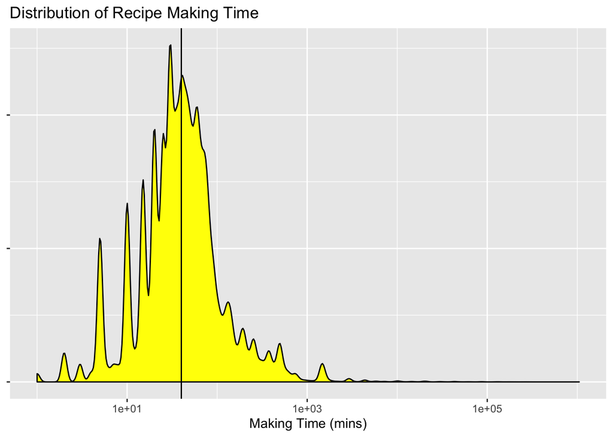

```r
nutritional_value %>%
  select(id, name, minutes) %>%
  filter(minutes < 2000000) %>%
  distinct() %>%
  ggplot(aes(minutes)) +
  geom_density(fill = "yellow") +
  geom_vline(xintercept = median(nutritional_value$minutes)) +
  scale_x_log10() +
  xlab("Making Time (mins)") +
  ylab(NULL) +
  theme(axis.text.y = element_blank()) +
  ggtitle("Distribution of Recipe Making Time")
```

```r
paste0("Median Recipe Making Time: ", median(nutritional_value$minutes), " Minutes")
```

```
## [1] "Median Recipe Making Time: 40 Minutes"
```

### Data collection and review

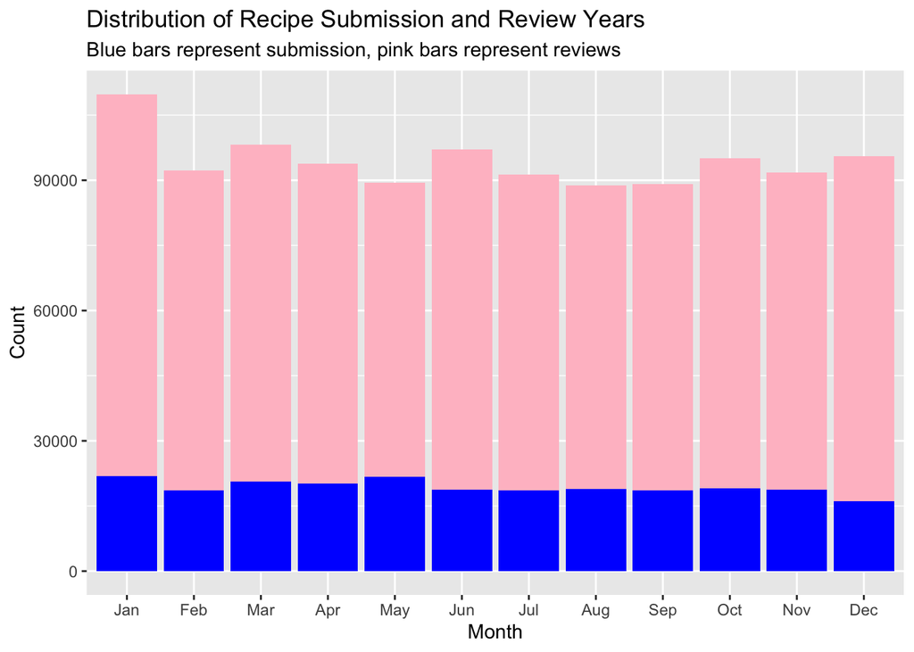

```r
submission_months <- nutritional_value %>%
  select(submission_month, id) %>%
  distinct()
review_months <- nutritional_value %>%
  select(review_month)

ggplot() +
  geom_bar(data = review_months, aes(review_month), fill = "pink") +
  geom_bar(data = submission_months, aes(submission_month), fill = "blue") +
  xlab("Month") +
  ylab("Count") +
  ggtitle("Distribution of Recipe Submission and Review Years", subtitle = "Blue bars represent submission, pink bars represent reviews")
```

January is the month in which majority of submissions were made and reviews were received. For the rest of the months, it is mostly the same amount of submissions and reviews. This data pointing towards January as a good month for submissions.

## Correlation Plot

Visualizing the relationship between time components and nutritional values

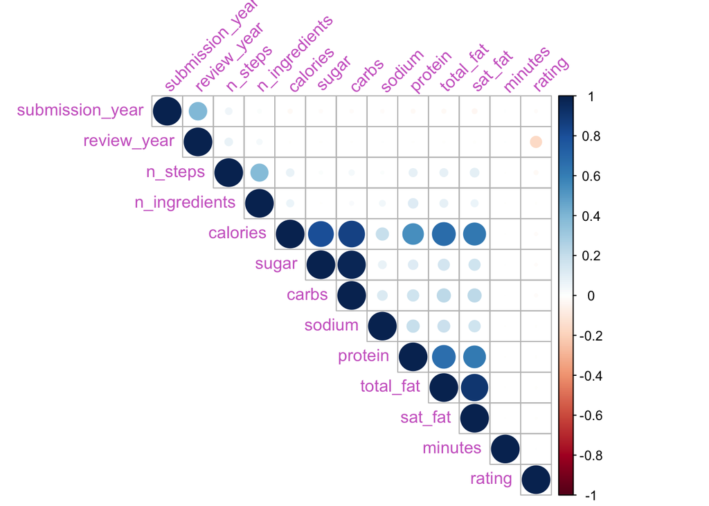

```r
correlation_values <- nutritional_value %>%
  select(minutes, 6:13, n_ingredients, rating, submission_year, review_year) %>%
  na.omit()

corrmatrix <- rcorr(as.matrix(correlation_values))

corrplot(corrmatrix$r, type = "upper", order = "hclust", tl.col = "orchid3", tl.srt = 45)
```

```r
corrmatrix$r
```

```
##                       minutes      calories     total_fat         sugar
## minutes          1.000000e+00 -0.0005133246 -0.0006509211  0.0002046224
## calories        -5.133246e-04  1.0000000000  0.6787733044  0.8020522067
## total_fat       -6.509211e-04  0.6787733044  1.0000000000  0.1598851107
## sugar            2.046224e-04  0.8020522067  0.1598851107  1.0000000000
## sodium          -9.457877e-04  0.1949717250  0.1838511877  0.0796699539
## protein         -1.140566e-03  0.5498750437  0.6695757639  0.1163202619
## sat_fat         -8.701156e-04  0.6283607142  0.9024231500  0.1608481991
## carbs            6.361270e-06  0.8590859433  0.2265292194  0.9712311297
## n_steps         -4.375907e-04  0.0745174236  0.0818710920  0.0139976843
## n_ingredients   -1.058933e-03  0.0657396992  0.0806437933 -0.0025790575
## rating           1.053435e-03 -0.0127847334 -0.0062817146 -0.0108258787
## submission_year  2.717389e-03 -0.0229866300 -0.0213149585 -0.0136018358
## review_year      1.695591e-03 -0.0052384066 -0.0057098666 -0.0038978237
##                        sodium      protein       sat_fat         carbs
## minutes         -0.0009457877 -0.001140566 -0.0008701156  6.361270e-06
## calories         0.1949717250  0.549875044  0.6283607142  8.590859e-01
## total_fat        0.1838511877  0.669575764  0.9024231500  2.265292e-01
## sugar            0.0796699539  0.116320262  0.1608481991  9.712311e-01
## sodium           1.0000000000  0.195564252  0.1668360715  1.216159e-01
## protein          0.1955642520  1.000000000  0.6155586045  1.653030e-01
## sat_fat          0.1668360715  0.615558604  1.0000000000  2.234716e-01
## carbs            0.1216159162  0.165302952  0.2234716169  1.000000e+00
## n_steps          0.0122009428  0.084019237  0.0984630179  3.729319e-02
## n_ingredients    0.0440288752  0.117755797  0.0644364901  2.138034e-02
## rating          -0.0041069541 -0.004563978 -0.0066065675 -1.276553e-02
## submission_year -0.0152823507 -0.020520559 -0.0302287753 -1.527386e-02
## review_year      0.0025485850 -0.003101163 -0.0077053579 -3.234087e-03
##                       n_steps n_ingredients       rating submission_year
## minutes         -0.0004375907  -0.001058933  0.001053435     0.002717389
## calories         0.0745174236   0.065739699 -0.012784733    -0.022986630
## total_fat        0.0818710920   0.080643793 -0.006281715    -0.021314959
## sugar            0.0139976843  -0.002579058 -0.010825879    -0.013601836
## sodium           0.0122009428   0.044028875 -0.004106954    -0.015282351
## protein          0.0840192367   0.117755797 -0.004563978    -0.020520559
## sat_fat          0.0984630179   0.064436490 -0.006606567    -0.030228775
## carbs            0.0372931894   0.021380340 -0.012765528    -0.015273859
## n_steps          1.0000000000   0.380295259 -0.021168589     0.057076116
## n_ingredients    0.3802952593   1.000000000 -0.003529497     0.019703786
## rating          -0.0211685888  -0.003529497  1.000000000    -0.012099788
## submission_year  0.0570761161   0.019703786 -0.012099788     1.000000000
## review_year      0.0757358986   0.036690227 -0.161640015     0.397514149
##                  review_year
## minutes          0.001695591
## calories        -0.005238407
## total_fat       -0.005709867
## sugar           -0.003897824
## sodium           0.002548585
## protein         -0.003101163
## sat_fat         -0.007705358
## carbs           -0.003234087
## n_steps          0.075735899
## n_ingredients    0.036690227
## rating          -0.161640015
## submission_year  0.397514149
## review_year      1.000000000
```